# Homework-1

Devlin Hoang

2026-04-12

## R Markdown

```r
library(rpart)
library(rpart.plot)
library(randomForest)
library(tidyr)
library(gbm)
library(caret)
library(dplyr)
set.seed(123)
```

Research Question:

How do tobacco-related behaviors and other youth characteristics predict cigarette initiations, smoking frequency, and smoking intensities among youths?

Load data

```r
youth_data<- read.csv('youth_data.csv')
```

Create binary outcome:

```r
#Binary classification:
youth_data$ever_cig<- ifelse(youth_data$IRCIGAGE== 991,0,1)
youth_data$ever_cig<-factor(youth_data$ever_cig)
summary(youth_data$ever_cig)
```

```
##    0    1
## 9796  765
```

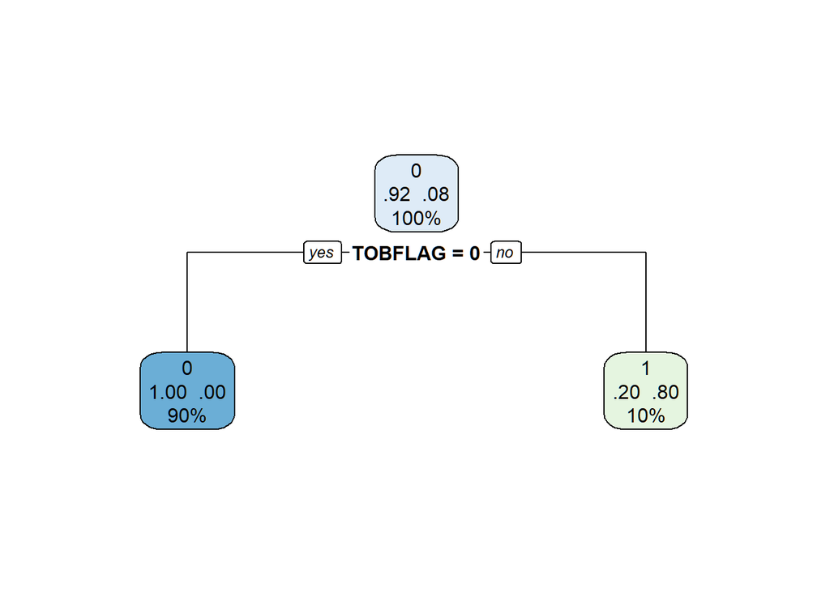

```r
#Train/test split:
train_idx<- createDataPartition(youth_data$ever_cig, p=0.7, list=FALSE)
train_bin<- youth_data[train_idx,]
test_bin<- youth_data[-train_idx,]

train_bin <- train_bin %>% drop_na()
test_bin<- test_bin %>% drop_na()

#CART model:
tree_bin<- rpart(
  ever_cig ~. -IRCIGAGE -IRCIGFM,
  data= train_bin,
  method= 'class',
  control= rpart.control(cp=0.01,minbucket= 50)
)
rpart.plot(tree_bin, type= 2, extra=104)
```

```r
#CART evaluation:
pred_tree_bin<-predict(tree_bin, test_bin, type='class')
confusionMatrix(pred_tree_bin, test_bin$ever_cig)
```

```
## Confusion Matrix and Statistics
##
##           Reference
## Prediction    0    1
##          0 2206    0
##          1   59  190
##
##                Accuracy : 0.976
##                  95% CI : (0.9691, 0.9817)
##     No Information Rate : 0.9226
##     P-Value [Acc > NIR] : < 2.2e-16
##
##                   Kappa : 0.8527
##
##  Mcnemar's Test P-Value : 4.321e-14
##
##             Sensitivity : 0.9740
##             Specificity : 1.0000
##          Pos Pred Value : 1.0000
##          Neg Pred Value : 0.7631
##              Prevalence : 0.9226
##          Detection Rate : 0.8986
##    Detection Prevalence : 0.8986
##       Balanced Accuracy : 0.9870
##
##        'Positive' Class : 0
##
```

```r
#Random Forest for binary classification:
rf_bin<- randomForest(
  ever_cig ~. - IRCIGAGE - IRCIGFM,
  data= train_bin,
  ntree= 300,
  mtry=5,
  importance= TRUE
)
rf_bin
```

```
##
## Call:
##  randomForest(formula = ever_cig ~ . - IRCIGAGE - IRCIGFM, data = train_bin,      ntree = 300, mtry = 5, importance = TRUE)
##                Type of random forest: classification
##                      Number of trees: 300
## No. of variables tried at each split: 5
##
##         OOB estimate of  error rate: 3.23%
## Confusion matrix:
##      0   1 class.error
## 0 5306  45 0.008409643
## 1  142 301 0.320541761
```

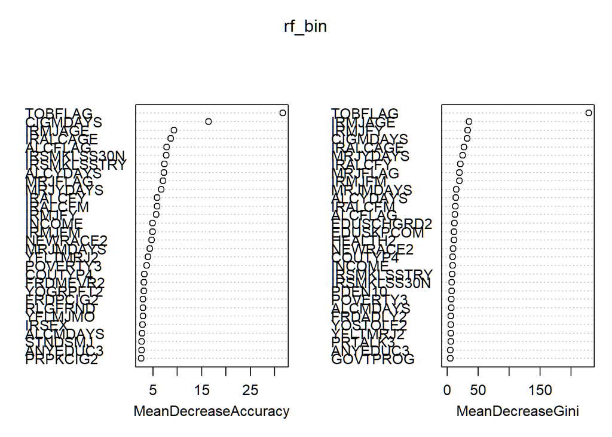

```r
varImpPlot(rf_bin)
```

```r
#RF evaluation:
pred_bin_rf<- predict(rf_bin, test_bin)
confusionMatrix(pred_bin_rf,test_bin$ever_cig)
```

```
## Confusion Matrix and Statistics
##
##           Reference
## Prediction    0    1
##          0 2242   67
##          1   23  123
##
##                Accuracy : 0.9633
##                  95% CI : (0.9551, 0.9704)
##     No Information Rate : 0.9226
##     P-Value [Acc > NIR] : < 2.2e-16
##
##                   Kappa : 0.7128
##
##  Mcnemar's Test P-Value : 5.826e-06
##
##             Sensitivity : 0.9898
##             Specificity : 0.6474
##          Pos Pred Value : 0.9710
##          Neg Pred Value : 0.8425
##              Prevalence : 0.9226
##          Detection Rate : 0.9132
##    Detection Prevalence : 0.9405
##       Balanced Accuracy : 0.8186
##
##        'Positive' Class : 0
##
```

Binary classification analysis predicting whether youth have ever used cigarettes showed a highly structured pattern that dominated by tobacco involvement. The decision tree showed TOBFLAG- a general indicator of tobacco exposure- is the single most decisive indicator. TOBFLAG= 0 means non-smoker with 100% purity, while TOBFLAF > 0 are individuals that exposed to tobacco before. This split captures almost all variations in cigarette initiation, underscoring how tobacco experience is the strongest dominant. Random forest plot reinforce tree-plot conclusion. TOBFLAG ranks above all predictors in both Mean Decrease Accuracy and Mean Decrease Gini, this confirm its dominant predictive power. The second variables like RMAAGE (age at first marijuana use) and RMDAYS(days of marijuana use) suggest that marijuana exposure may correlate with cigarette initiation, but it does not rival tobacco involvement. from two models, tobacco exposure alone is sufficient to classify youth smoking status is high accuracy, other variables only add minor refinements to the model.